# Scrollytelling in Quarto

Daten in Bewegung

Author

Caroline Gasser

Published

August 25, 2026

Scrollytelling mit Closeread in Quarto bietet eine einfache Low-Code-Lösung, um interaktive, dynamische und aufmerksamkeitsstarke Scrollytelling-Formate zu erstellen.

Die kleine Demo zeigt beispielhaft, wie Scrollytelling funktionieren kann. Sie dient dabei ausschliesslich zur Veranschaulichung der Möglichkeiten und als kurzer Einstieg in das Format.

**Scrollytelling Output**

Die Grafik zeigt den Zusammenhang zwischen Fahrzeuggewicht und Kraftstoffverbrauch.

Zusätzlich ist eine lineare Trendlinie dargestellt, die den allgemeinen Zusammenhang zwischen den beiden Variablen verdeutlicht.

Das 95%-Vertrauensintervall zeigt, in welchem Bereich die wahre Trendlinie mit hoher Wahrscheinlichkeit liegt.

Man sieht, dass mit zunehmendem Fahrzeuggewicht (Weight) die Reichweite (Miles per Gallon) abnimmt.

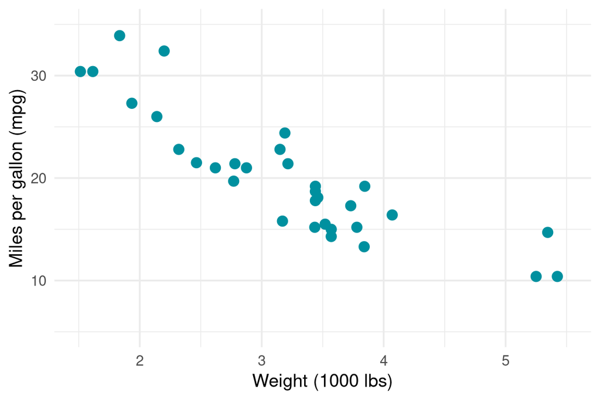

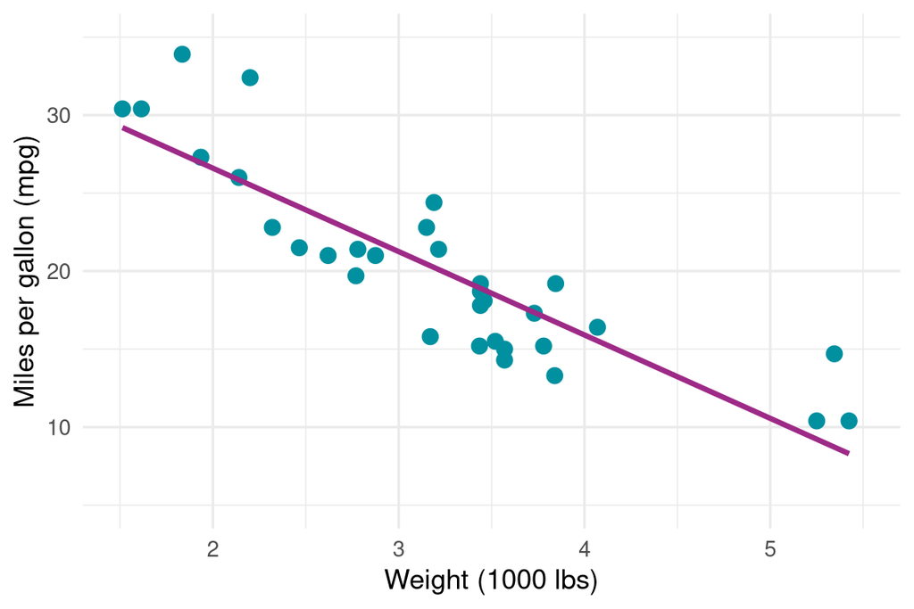

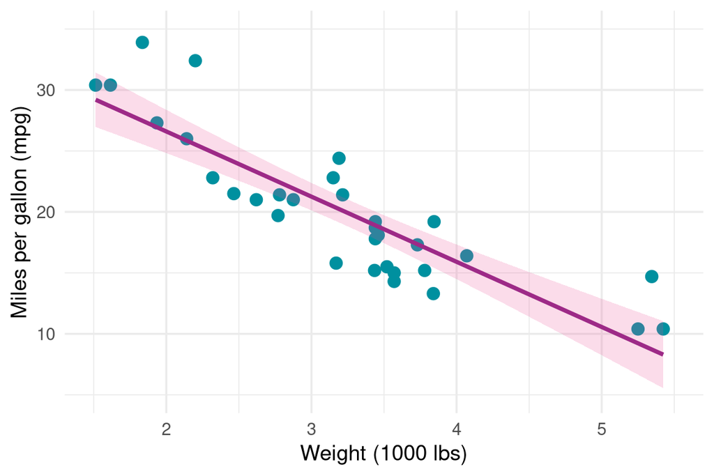

**Code**

````r
--- #YAML-Header

format:
  closeread-html:
    cr-section:
      layout: "overlay-left"
    cr-style:
      narrative-background-color-overlay: "#63B9C2"
      narrative-text-color-overlay: "black"
      section-background-color: "white"
---

::::{.cr-section} #öffnet Scrollytelling Section

:::{#cr-plot1}  #1. Sticky-Element
```{r, echo=FALSE, fig.width=6, fig.height=4}

ggplot(mtcars, aes(x = wt, y = mpg)) +
  geom_point(
    size = 3,
    color = cd_tuerkis
  ) +
  labs(
    x = "Weight (1000 lbs)",
    y = "Miles per gallon (mpg)"
  ) +
      xlim(1.5, 5.5) +
    ylim(5, 35)+
  theme_minimal(base_size = 13)
```
::: # Ende 1. Sticky-Element

Die Grafik zeigt den Zusammenhang zwischen Fahrzeuggewicht
und Kraftstoffverbrauch. @cr-plot1 #Narrativ & Trigger für 1. Sticky-Element

:::{#cr-plot2} # 2. Sticky-Element
```{r, echo=FALSE, message = FALSE, fig.width=6, fig.height=4}
ggplot(mtcars, aes(x = wt, y = mpg)) +
  geom_point(
    size = 3,
    color = cd_tuerkis
  ) +
    geom_smooth(
    method = "lm",
    se = FALSE,
    color = cd_violett,
    alpha = 0.20,
    linewidth = 1.2
  ) +
  labs(
    x = "Weight (1000 lbs)",
    y = "Miles per gallon (mpg)"
  ) +
      xlim(1.5, 5.5) +
    ylim(5, 35)+
  theme_minimal(base_size = 13)
```
::: # Ende 2. Sticky-Element

Zusätzlich ist eine lineare Trendlinie dargestellt,
die den allgemeinen Zusammenhang zwischen
den beiden Variablen verdeutlicht.  @cr-plot2 #Narrativ & Trigger für 2. Sticky-Element

:::{#cr-plot3} # 3. Sticky-Element
```{r, echo=FALSE,message = FALSE, fig.width=6, fig.height=4}
ggplot(mtcars, aes(x = wt, y = mpg)) +
  geom_point(
    size = 3,
    color = cd_tuerkis
  ) +
  geom_smooth(
    method = "lm",
    se = TRUE,
    color = cd_violett,
    fill = cd_magenta,
    alpha = 0.20,
    linewidth = 1.2
  ) +
  labs(
    x = "Weight (1000 lbs)",
    y = "Miles per gallon (mpg)"
  ) +
    xlim(1.5, 5.5) +
    ylim(5, 35)+
  theme_minimal(base_size = 13)
```
::: # Ende 3. Sticky-Element

Das 95%-Vertrauensintervall zeigt,
in welchem Bereich die wahre Trendlinie
mit hoher Wahrscheinlichkeit liegt. @cr-plot3 # Narrativ & Trigger 3. Sticky-Element

Man sieht, dass mit zunehmendem Fahrzeuggewicht (Weight)
die Reichweite (Miles per Gallon) abnimmt. # Narrativ ohne neues Sticky-Element

:::: # Ende Scrollytelling Section
````

# 1. Einleitung

Der Begriff «Scrollytelling» kombiniert Storytelling mit dem Scrollen durch digitale Inhalte und beschreibt eine Webdesign-Technik, bei der sich Inhalte (z.B. Text, Bilder, Animationen oder Datenvisualisierungen) dynamisch verändern oder animieren, während Nutzerinnen und Nutzer auf einer Seite nach unten scrollen. Zentrales Merkmal ist die Multimedialität, insbesondere die enge Verknüpfung von Text und visuellen Elementen. Darüber hinaus ist Scrollytelling intuitiv und leicht bedienbar.  
**Wofür ist Scrollytelling gut?**

- **Verständnis komplexer Inhalte**
  - erleichtert das Verständnis komplexer Daten und Zusammenhänge
- **Aufmerksamkeit & Nutzerbindung**
  - erzeugt ein ansprechendes, interaktives Leseerlebnis
  - steigert die Aufmerksamkeit der Nutzerinnen und Nutzer
- **Innovation & mediale Wirkung**
  - ermöglicht sogenannte Leuchtturmprojekte (Signalwirkung)
  - hilft, sich innovativ und modern zu positionieren
- **Zielgruppenwirkung**
  - besonders attraktiv für jüngere Zielgruppen (unter 35 Jahren), diese reagieren stärker auf Innovation und Unterhaltungswert
  - durch die schrittweise Vermittlung von Erklärungen und zusätzlichen Informationen in Grafiken lassen sich Inhalte gezielt auf unterschiedliche Zielgruppen abstimmen

**Wofür ist Scrollytelling nicht gut?**  
Der Zeitaufwand ist etwas höher als bei herkömmlichen Darstellungen, reduziert sich jedoch mit zunehmender Erfahrung. Daher eignet sich Scrollytelling weniger für die alltägliche Darstellung von Inhalten, sondern vielmehr für einen gezielten Einsatz.

# 2. Technische Umsetzung

Im Folgenden wird gezeigt, wie Scrollytelling mit Closeread in Quarto technisch umgesetzt werden kann.

Closeread ist ein benutzerdefiniertes Format für Quarto, das Scrollytelling-Funktionen für HTML-Dokumente ermöglicht ([Zur Webseite](https://closeread.dev/)).

Für die Erstellung eines Scrollytelling-Dokuments muss zunächst ein neues Quarto-Dokument erstellt und die Closeread-Extention installiert werden. Dazu wird der entsprechende Befehl in dem Verzeichnis ausgeführt, in dem die Erweiterung verwendet werden soll.

```r
quarto add qmd-lab/closeread
```

Anschliessend ist der YAML-Header im oberen Bereich des Dokuments wie folgt anzupassen:

```r
---
title: My First Closeread
format: closeread-html
---
```

Jedes Closeread-Dokument besteht aus drei zentralen Komponenten: Abschnitten (Sections), Stickies und Triggern.

Ein Abschnitt ist ein Bereich des Dokuments, der explizit als Closeread- bzw. Scrollytelling-Abschnitt gekennzeichnet wird. Innerhalb dieses Abschnitts können sogenannte «Sticky»-Elemente definiert werden. Diese bleiben sichtbar, während die Nutzerin oder der Nutzer durch den Inhalt scrollt. Sie bleiben in der Hauptansicht fixiert und scrollen nicht mit. Zusätzlich benötigt es ein Element, meist einen Absatz, das als Auslöser (Trigger) dient und bestimmt, wann ein Sticky eingeblendet wird.

## 2.1 Section

Ein Closeread-Abschnitt (Section) wird wie folgt definiert:

```r
::::{.cr-section}      #öffnet Abschnitt
< Absätze, Bilder, Code-Zellen usw. >
::::                   #schliesst Abschnitt
```

Damit lassen sich ein oder mehrere Closeread-Abschnitte in ein gewöhnliches HTML- oder Quarto-Dokument integrieren. Wenn man das gesamte Dokument in eine solche `cr-section`-Umgebung einbettet, entsteht ein vollständiges Closeread-Dokument. Standardmässig werden alle Inhalte innerhalb eines Abschnitts als fortlaufende Erzählung dargestellt und scrollen normal durch, es sei denn, sie wurden explizit als Sticky definiert.

## 2.2 Stickes

Stickies sind Elemente, die beim Scrollen an einer festen Position auf dem Bildschirm (mitte, recht, links) «haften bleiben», ähnlich wie eine Notiz. Während der restliche Inhalt weiter scrollt, bleibt das Sticky-Element sichtbar.

Ein Sticky wird wie folgt definiert:

```r
:::{#cr-StickyID}
Inhalt des Sticky-Elements
:::
```

Wichtig ist, dass jedes Sticky eine eindeutige ID (einen Namen) erhält. Die Syntax ist unabhängig vom Inhalt: Ob Bild, Textabsatz, Liste, mathematischer Ausdruck oder Code, jedes Element kann als Sticky definiert werden, indem es in diese Struktur eingebettet wird. In der Praxis verwendet man häufig mehrere Stickies, die sich im Verlauf der Erzählung abwechseln.

Es wird empfohlen, die Struktur der Closeread-Abschnitte durch die Verwendung unterschiedlich vieler Colons `(:)` klar zu trennen. Dadurch lassen sich Section- und Sticky-Elemente leichter unterscheiden und die Lesbarkeit verbessern.

Für einen Closeread-Abschnitt werden beispielsweise vier Colons `(::::)` und für ein Sticky-Element drei Colons `(:::)` verwendet:

```r
::::{.cr-section}

::: {#cr-StickyID}
Inhalt des Sticky-Elements
:::

::::
```

Einige Beispiele für Sticky-Inhalte:

````r
::: {#cr-Sticky1}
[ ](/pfad/zu/Bild.png) #Bild als Sticky
:::

::: {#cr-Sticky2}
[ ](/pfad/zu/eingif.GIF) #GIF als Sticky
:::

::: {#cr-Sticky3}
```{r}
plot(cars$wt ~ cars$mpg) #Rplot als Sticky
```
:::
````

## 2.3 Trigger

Damit ein Sticky tatsächlich angezeigt wird, muss es durch einen Trigger aktiviert werden. Ein Sticky erscheint also nicht automatisch, nur weil es definiert wurde.

Der einfachste Trigger ist eine Referenz (@) auf die Sticky-ID innerhalb eines Absatzes:

```r
Dieser Satz triggert das Sticky @cr-StickyID
```

Normalerweise sind Trigger an ein Narrativ gekoppelt, also an einen erklärenden oder erzählenden Text.

Der Trigger kann an beliebiger Stelle im Text stehen, sollte jedoch durch Leerzeichen vom restlichen Inhalt getrennt sein.

Wenn mehrere zusammenhängende Textblöcke (z.B. zwei Absätze) als Einheit stehen und gemeinsam als ein Trigger fungieren sollen, können sie eingebettet werden:

```r
:::{focus-on="cr-StickyID"}
Dieser Absatz und der folgende erscheinen als zusammenhängender Erzählblock
Sobald diese Abschnitte in den sichtbaren Bereich scrollen,
wird das Sticky "cr-StickyID" eingeblendet.
:::
```

Ein Narrativ kann auch ohne eigenen Trigger verwendet werden. In diesem Fall aktiviert es kein neues Sticky, sondern dient als zusätzliche Information zum zuvor getriggerten Sticky.

## 2.4 Layout

Die Anordnung der Narrative und Stickies bestimmt das Layout des Scrollytelling-Abschnitts. Folgende Layouts stehen zur Verfügung:

- `sidebar-left`: Default, narrative Textblöcke erscheinen links, die visuellen Inhalte rechts.
- `sidebar-right`: Narrative Textblöcke erscheinen rechts, die visuellen Inhalte links.
- `overlay-left`: Narrative Textblöcke werden als Overlay über den linken Bereich der visuellen Inhalte gelegt.
- `overlay-center`: Mobile Version (automatisch), narrative Textblöcke werden zentral als Overlay über den Bereich der visuellen Inhalte gelegt.
- `overlay-right`: Narrative Textblöcke werden als Overlay über den rechten Bereich der visuellen Inhalte gelegt.

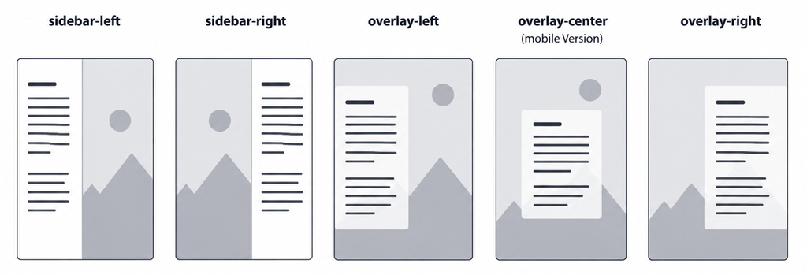

Das Layout eines Abschnitts kann über das Attribut `layout` im entsprechenden Abschnittsblock definiert werden:

```r
::::{.cr-section layout="overlay-center"}
< Content of the section, including stickies and narrative blocks >
::::
```

Dokumente mit mehreren Closeread-Abschnitten können entweder unterschiedliche Layouts verwenden oder ein gemeinsames Layout für alle Abschnitte festlegen. Alternativ zur Definition innerhalb jedes Abschnitts kann das Layout auch global im YAML-Header des Dokuments definiert werden:

```r
---
format:
  closeread-html:
    cr-section:
      layout: "overlay-center"
---
```

## 2.5 Optionen

Closeread-Dokumente orientieren sich standardmässig am verwendeten Quarto-Theme. Für eine individuellere Gestaltung der Closeread-Abschnitte können jedoch zusätzliche Stiloptionen definiert werden. Werden diese im YAML-Header als globale Optionen festgelegt, gelten sie für alle Abschnitte des Dokuments und sorgen für ein einheitliches Erscheinungsbild.

```r
---
format:
  closeread-html:
    cr-style:
      narrative-background-color-overlay: darkslategrey
      narrative-text-color-overlay: "#e2e2e2"
---
```

Closeread unterstützt die Einbindung von CSS- oder SCSS-Dateien, mit denen das Erscheinungsbild von Closeread-Abschnitten individuell angepasst werden kann.

```r
---
format:
  closeread-html:
    css: file.css
---
```

# 3. Veröffentlichung

## 3.1 Anforderungen

Beim Rendern des Dokuments ist es wichtig, einen self-contained (eigenständig lauffähigen) Output zu erzeugen, insbesondere wenn externe CSS-Dateien eingebunden werden. Das bedeutet, dass alle benötigten Ressourcen direkt in die HTML-Datei eingebettet werden. Andernfalls wird das Styling möglicherweise nicht korrekt übernommen, wenn die HTML-Datei separat geöffnet wird.

```r
---
format:
  closeread-html:
    self-contained: true
---
```

Vor der Veröffentlichung ist abzuklären, in welchem Format veröffentlicht wird und welcher verfügbare Seitenplatz zur Verfügung steht. Insbesondere in gewissen Content-Management-Systemen (CMS) können die verfügbaren Platzverhältnisse stark eingeschränkt sein, was die Gestaltung von narrativen und interaktiven («sticky») Elementen beeinflussen kann.

## 3.1 Publikationsprozess

Der standalone HTML-Output kann direkt über Quarto oder andere Webplattform veröffentlicht werden.

Für die Veröffentlichung in einem CMS kann der generierte HTML-Code verwendet werden. Dieser wird beispielsweise in einem Editor wie Visual Studio Code geöffnet, vollständig kopiert und anschliessend im Bearbeitungsmodus des CMS eingefügt.

## 3.2 Desktop vs. Mobile Version

Die Closeread-Extension stellt in der mobilen Version das Layout automatisch auf `overlay-center` um.

Sofern man mit Optionen und speziellen Formatvorgaben via CSS arbeitet, muss man im Auge behalten, dass diese für die mobile Version eventuell nicht förderlich sind.

Zusätzlich müssen sowohl der Light- als auch der Dark-Mode berücksichtigt werden, da narrative Inhalte im Dark Mode schwer lesbar sein können und «sticky» Elemente im visuell unästhetisch wirken können. Daher sollte über die CSS-Datei sichergestellt werden, dass gegebenenfalls eine der beiden Darstellungsvarianten gezielt erzwungen wird.

Im CSS-File:

```r
:root {
  color-scheme: light only;
}
```

## 3.3 Videoformat

Um Scrollytelling in ein Videoformat zu bringen, gibt es verschiedene Varianten. Am einfachsten ist es, das Dokument in einem neuen Tab zu rendern, über F12 die Entwicklertools zu öffnen und die gewünschten Scroll-Positionen und Stopps festzulegen. Anschliessend wird das Dokument mit einem Autoscroll-Skript automatisch durchlaufen und dabei eine Bildschirmaufnahme erstellt.

# 4. Dank

Herzlichen Dank an das Amt für Daten und Statistik Thurgau, dass ich die Möglichkeit erhalten habe, diese Anwendung kennenzulernen, umzusetzen und an den Schweizer Statistiktagen präsentieren zu dürfen.

Ich bedanke mich herzlich für die Möglichkeit, die wertvolle Unterstützung und das entgegengebrachte Vertrauen.

# 5. Literatur

Tjärnhage A, Söderström U, Norberg O, Andersson M, Mejtoft T. The Impact of Scrol-lytelling on the Reading Experience of Long-Form Journalism. In: Proceedings of the European Conference on Cognitive Ergonomics 2023. New York, NY, USA: Association for Computing Machinery; 2023. S. 1–9. (ECCE ’23). Verfügbar unter: https://dl.acm.org/doi/10.1145/3605655.3605683 doi:10.1145/3605655.3605683

Sultanum N, Chevalier F, Bylinskii Z, Liu Z. Leveraging Text-Chart Links to Support Authoring of Data-Driven Articles with VizFlow. In: Proceedings of the 2021 CHI Con-ference on Human Factors in Computing Systems. New York, NY, USA: Association for Computing Machinery; 2021. S. 1–17. (CHI ’21). Verfügbar unter: https://dl.acm.org/doi/10.1145/3411764.3445354 doi:10.1145/3411764.3445354

Godulla A, Wolf C. Digitale Langformen im Journalismus und Corporate Publishing. Wiesbaden: Springer Fachmedien; 2017. Verfügbar unter: https://link.springer.com/book/10.1007/978-3-658-17556-6 doi:10.1007/978-3-658-17556-6

Seyser D, Zeiller M. Scrollytelling – An Analysis of Visual Storytelling in Online Jour-nalism. In: 2018 22nd International Conference Information Visualisation (IV). 2018. S. 401–6. Verfügbar unter: https://ieeexplore.ieee.org/document/8564193 doi:10.1109/iV.2018.00075

Vaih-Baur C. Scrollytelling. In: Femers-Koch S, Molthagen-Schnöring S, Herausgeber. Textspiele in der Wirtschaftskommunikation: Texte und Sprache zwischen Normierung und Abweichung. Wiesbaden: Springer Fachmedien; 2018. S. 343–6. Verfügbar unter: https://doi.org/10.1007/978-3-658-18899-3_14 doi:10.1007/978-3-658-18899-3_14

# 6. Kontakt

Amt für Daten und Statistik Thurgau

Caroline Gasser  
Hochschulpraktikantin Datenanalyse & Statistik  
Grabenstrasse 8  
8510 Frauenfeld  
T +41 58 345 53 68  
caroline.gasser@tg.ch

[Linkedin Amt für Daten und Statistik](https://www.linkedin.com/company/amt-f%C3%BCr-daten-und-statistik-thurgau)

[Linkedin privat](https://www.linkedin.com/in/cgasser/)